# R Tutorial 006: lubridate

RichardOnData

9/22/2020

```r
library(tidyverse)
library(nycflights13)
library(lubridate)
```

We will explore the “lubridate” package of the tidyverse. In this tutorial we will do the following things:

1. Creating date & datetime objects
2. Isolating components of the datetime
3. Time spans (durations, periods, intervals)

Please note that some of the code in this tutorial was adapted from Chapter 16 of the book “R for Data Science” by Hadley Wickham and Garrett Grolemund. The full book can be found at: https://r4ds.had.co.nz/#

A good cheat sheet for lubridate functions can be found at: https://rstudio.com/resources/cheatsheets/

A vignette for lubridate can be found here: https://cran.r-project.org/web/packages/lubridate/vignettes/lubridate.html And the following is a good reference: https://lubridate.tidyverse.org/reference/lubridate-package.html

### Creating datetime objects

Two key functions to be aware of are `today()` and `now()`. Observe the results:

```r
day <- today()
str(day)
```

```
##  Date[1:1], format: "2020-09-22"
```

The `today()` function returns the current date, and it is an object of class “Date”.

```r
datetime <- now()
str(datetime)
```

```
##  POSIXct[1:1], format: "2020-09-22 12:51:09"
```

The `now()` function requires the current datetime. This is an object of class “POSIXct”. “POSIXct” is the most common class in R for datetimes. These store the number of seconds since an origin point of “1970-01-01 00:00:00 UTC”, whereas the “Date” class stores the number of days since “1970-01-01”.

Now, let’s suppose these were stored as strings.

```r
string1 <- "2020-09-22"
string2 <- "2020-09-22 17:00:00"
str(string1)
```

```
##  chr "2020-09-22"
```

```r
str(string2)
```

```
##  chr "2020-09-22 17:00:00"
```

These are automatically stored as strings. Compare the following approaches now though:

```r
date1 <- as.Date(string1)
date2 <- as_date(string1)
datetime1 <- as.POSIXct(string2)
datetime2 <- as_datetime(string2)
str(date1)
```

```
##  Date[1:1], format: "2020-09-22"
```

```r
str(date2)
```

```
##  Date[1:1], format: "2020-09-22"
```

```r
str(datetime1)
```

```
##  POSIXct[1:1], format: "2020-09-22 17:00:00"
```

```r
str(datetime2)
```

```
##  POSIXct[1:1], format: "2020-09-22 17:00:00"
```

The functions `as.Date()` and `as.POSIXct()` come from base R. However, the `as_date()` and `as_datetime()` functions come from “lubridate”. However, `as_datetime()` is a little easier to write and remember than `as.POSIXct()`!

```r
dateFormat1 <- "20200922"
dateFormat2 <- "09-22-2020"
dateFormat3 <- "22/09/2020"
dateFormat4 <- "09-22-2020 17:00:00"
dateFormat5 <- "20200922 170000"
ymd(dateFormat1)
```

```
## [1] "2020-09-22"
```

```r
mdy(dateFormat2)
```

```
## [1] "2020-09-22"
```

```r
dmy(dateFormat3)
```

```
## [1] "2020-09-22"
```

```r
mdy_hms(dateFormat4)
```

```
## [1] "2020-09-22 17:00:00 UTC"
```

```r
ymd_hms(dateFormat5)
```

```
## [1] "2020-09-22 17:00:00 UTC"
```

### Isolating components of the datetime

Let’s look at today’s date. There are number of functions such as `year()`, `month()`, `mday()` (day of the month), `hour()`, `minute()`, `second()`, as well as helper functions like `yday()` and `wday()`.

```r
todayDate <- "2020-09-22 17:15:00"
year(todayDate)
```

```
## [1] 2020
```

```r
month(todayDate)
```

```
## [1] 9
```

```r
mday(todayDate)
```

```
## [1] 22
```

```r
hour(todayDate)
```

```
## [1] 17
```

```r
minute(todayDate)
```

```
## [1] 15
```

```r
second(todayDate)
```

```
## [1] 0
```

```r
yday(todayDate)
```

```
## [1] 266
```

```r
wday(todayDate)
```

```
## [1] 3
```

With the functions `month()` and `wday()`, you can specify the argument `label = TRUE`. Observe:

```r
month(todayDate, label = TRUE)
```

```
## [1] Sep
## 12 Levels: Jan < Feb < Mar < Apr < May < Jun < Jul < Aug < Sep < ... < Dec
```

```r
wday(todayDate, label = TRUE)
```

```
## [1] Tue
## Levels: Sun < Mon < Tue < Wed < Thu < Fri < Sat
```

Let’s illustrate the usefulness of these functions by loading the `flights` data and creating a couple visualizations.

```r
data <- flights %>%
  dplyr::select(flight, carrier, time_hour)
data
```

```
## # A tibble: 336,776 x 3
##    flight carrier time_hour
##     <int> <chr>   <dttm>
##  1   1545 UA      2013-01-01 05:00:00
##  2   1714 UA      2013-01-01 05:00:00
##  3   1141 AA      2013-01-01 05:00:00
##  4    725 B6      2013-01-01 05:00:00
##  5    461 DL      2013-01-01 06:00:00
##  6   1696 UA      2013-01-01 05:00:00
##  7    507 B6      2013-01-01 06:00:00
##  8   5708 EV      2013-01-01 06:00:00
##  9     79 B6      2013-01-01 06:00:00
## 10    301 AA      2013-01-01 06:00:00
## # ... with 336,766 more rows
```

First, let’s create a bar chart of the count of flights by month:

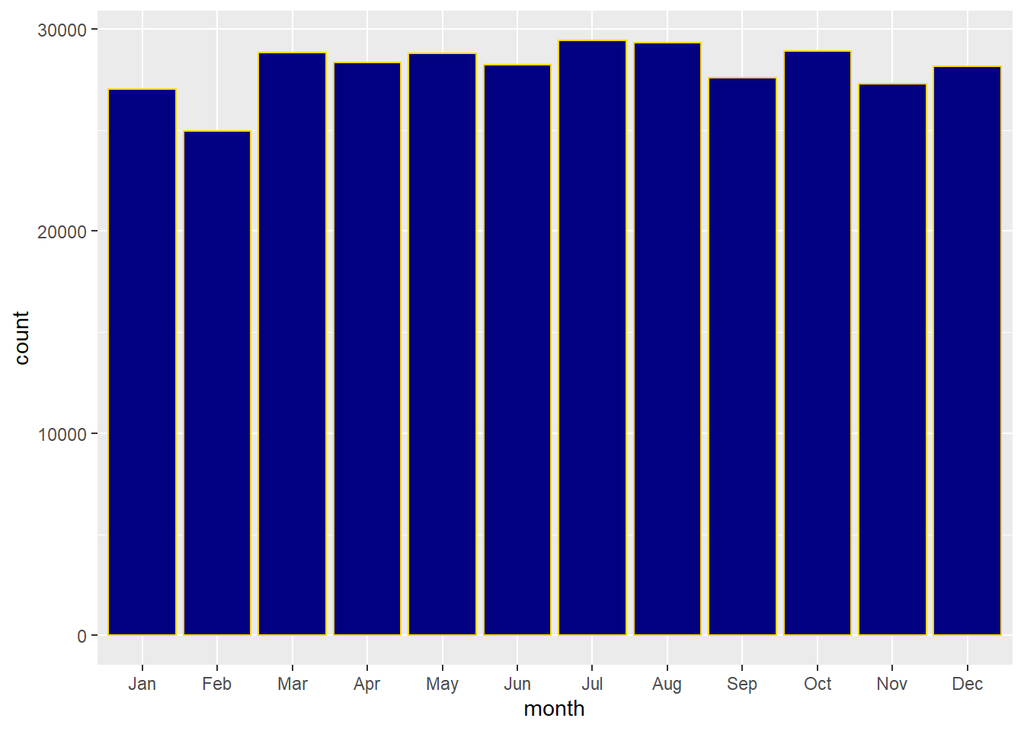

```r
data %>%
  mutate(month = month(time_hour, label = TRUE)) %>%
  ggplot() +
  geom_bar(aes(x = month), fill = "navy", color = "gold")
```

Next, let’s create a line plot for flights by hour of the day:

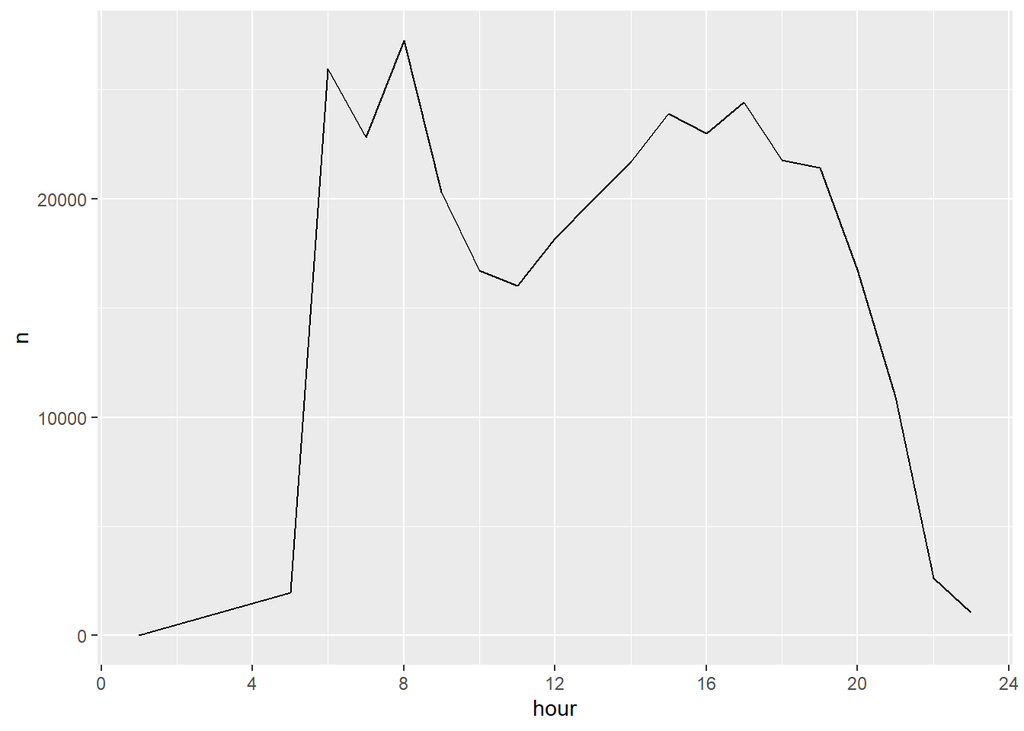

```r
data %>%
  mutate(hour = hour(time_hour)) %>%
  group_by(hour) %>%
  tally() %>%
  ggplot() +
  geom_line(aes(x = hour, y = n)) +
  scale_x_continuous(breaks = seq(0, 24, 4))
```

### Time spans (durations, periods, intervals)

The definition of these three classes are as follows:

- Durations measure the exact number of seconds that occur between two instants.
- Periods measure the change in clock time that occurs between two instants.
- Intervals are timespans representing a start and an end point.

```r
startDate <- as_datetime("2020-03-01 00:00:00")
endDate <- as_datetime("2020-03-31 23:59:59")
difftime <- endDate - startDate
difftime
```

```
## Time difference of 30.99999 days
```

```r
as.duration(difftime)
```

```
## [1] "2678399s (~4.43 weeks)"
```

```r
as.period(difftime)
```

```
## [1] "30d 23H 59M 59S"
```

```r
as.interval(startDate, endDate)
```

```
## [1] 2020-03-01 UTC--2020-03-31 23:59:59 UTC
```

Durations make it easy to add durations of time to existing datetimes. They come with a variety of helper functions such as `dseconds()`, `dminutes()`, `dhours()`, `ddays()`, `dweeks()`, `dmonths()`, and `dyears()`.  
Periods are similar and come with similar helper functions: `seconds()`, `minutes()`, `hours()`, `days()`, `months()`, `weeks()`, and `years()`. Here are examples that will return the same result:

```r
startDate + dhours(5)
```

```
## [1] "2020-03-01 05:00:00 UTC"
```

```r
startDate + minutes(300)
```

```
## [1] "2020-03-01 05:00:00 UTC"
```

However, here is an example where they will return DIFFERENT results:

```r
stTime <- ymd_hms("2020-03-07 12:00:00", tz = "America/New_York")
stTime + ddays(1)
```

```
## [1] "2020-03-08 13:00:00 EDT"
```

```r
stTime + days(1)
```

```
## [1] "2020-03-08 12:00:00 EDT"
```

Intervals also come with a variety of helper functions like `int_start()`, `int_end()`, `int_flip()`, `int_shift()`, `int_overlaps()`, `int_standardize()`, `int_aligns()`, and `int_diff()`. These can be accessed through the help documentation and are fairly intuitive.